# Tutorial on ordinal regressions in R

Christophe Bousquet

2023-08-03

# Ordinal regressions in R

As any other regressions, ordinal regressions can be done either within a frequentist or within a Bayesian framework. For the frequentist approach, we will use the `ordinal` package. For the Bayesian approach, we will use the `brms` package. We will also see how ordinal regressions compare to logistic or linear regressions. For this, we will use the `lme4` package.

Let’s first prepare the data.

## 1. Data preparation

Load all necessary packages. You may need to first install the packages by running commands of the type `install.packages("package name")` (do not forget the `""`).

```r
library(tidyverse) # for data handling and visualization (ggplot2)
library(ordinal) # for frequentist approach of ordinal regression
library(lme4) # for frequentist approach of logistic and linear regressions
library(brms) # for Bayesian approach of regressions
library(paletteer) # for additional colour palettes
library(ggthemes) # for additional themes
```

Load the dataset for this tutorial (“Ordinal regression.csv”), wherever it is located on your machine. This dataset contains fake data comprising 6 groups, in which two individuals are dominant and the others are subordinates. The foraging success is assumed to have been assessed empirically for each test and high values for this variable mean that individuals had a high foraging success. All groups are tested 3 times and their group composition does not change across tests. Between groups, group size is not necessarily the same.

```r
ORE <- read.csv(file.choose(), header = TRUE)
```

Specify that `Arrival.order` is an ordered factor [essential step for ordinal regressions] and also create a binary outcome [first vs rest] for the logistic regression.

```r
ORE <- ORE %>%
  mutate(Arrival.order = factor(Arrival.order, ordered = TRUE),
         Group = factor(Group),
         Test = factor(Test),
         Individual = factor(Individual),
         Status = factor(Status),
         Arrival.bin = ifelse(Arrival.order == 1, 1, 0))
```

## 2. Summary of the observed data

The following plot displays the observed arrival order separated by dominance status:

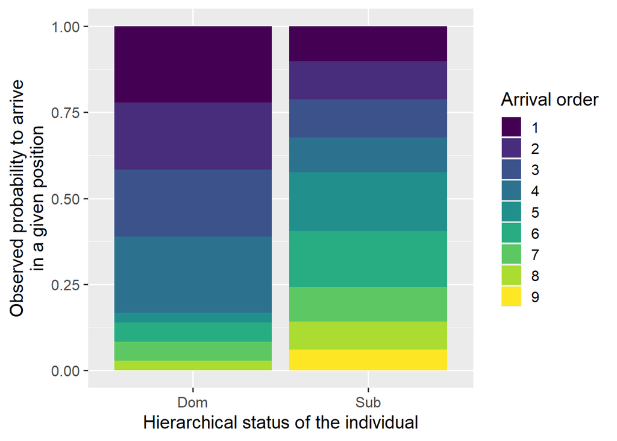

```r
ORE %>%
  group_by(Status, Arrival.order) %>%
  summarize(Arrival.order.perc = n() / 135) %>% # 135 is the total number of observations
  ungroup() %>%
  ggplot(aes(x = Status, y = Arrival.order.perc, fill = Arrival.order)) +
  geom_bar(position = "fill", stat = "identity") +
  labs(x = "Hierarchical status of the individual",
       y = "Observed probability to arrive\nin a given position",
       fill = "Arrival order") +
  theme_gray(base_size = 15)
```

```r
# if you want, you can save this graph
#ggsave("ORE_observed_Status.png", width = 8, height = 5, dpi = 600)
```

The following plot displays the observed arrival order separated by foraging success:

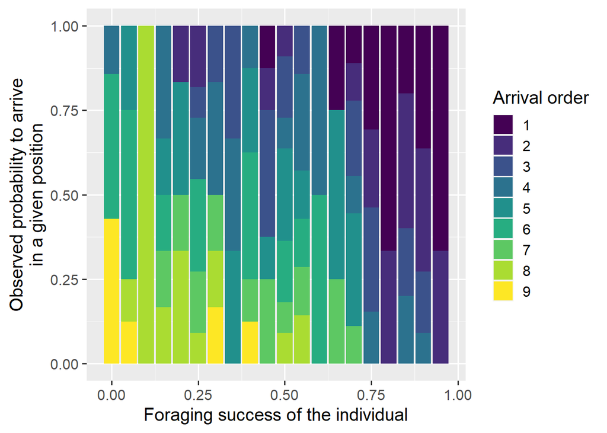

```r
ORE %>%
  mutate(Foraging.success.bin = cut(Foraging.success, seq(0, 1, 0.05), labels = seq(0, 0.95, 0.05), right = FALSE)) %>%
  mutate(Foraging.success.bin = as.numeric(as.character(Foraging.success.bin))) %>%
  group_by(Foraging.success.bin, Arrival.order) %>%
  summarize(Arrival.order.perc = n() / 135) %>%
  ungroup() %>%
  ggplot(aes(x = Foraging.success.bin, y = Arrival.order.perc, fill = Arrival.order)) +
  geom_bar(position = "fill", stat = "identity") +
  labs(x = "Foraging success of the individual",
       y = "Observed probability to arrive\nin a given position",
       fill = "Arrival order") +
  theme_gray(base_size = 15)
```

```r
# if you want, you can save this graph
#ggsave("ORE_observed_ForagingSuccess.png", width = 8, height = 5, dpi = 600)
```

## 3. Frequentist approach

### 3A. Ordinal regression using `clmm()` (from the “`ordinal`” package)

#### 3A_1. Modelling

The ordinal package comes with one limitation: it cannot use nested random effects [Test within Group in our case]. However, you can choose all three terms [Group, Test and Individual] as random effects, but not nested. The model evaluates whether Arrival order can be explained by an interaction between an individual’s dominance status and its foraging success.

```r
ORE_clmm <- clmm(Arrival.order ~ Status * Foraging.success + (1|Group) + (1|Test) + (1|Individual), data = ORE)
summary(ORE_clmm)
```

```
## Cumulative Link Mixed Model fitted with the Laplace approximation
##
## formula: Arrival.order ~ Status * Foraging.success + (1 | Group) + (1 |
##     Test) + (1 | Individual)
## data:    ORE
##
##  link  threshold nobs logLik  AIC    niter      max.grad cond.H
##  logit flexible  135  -241.58 511.17 2590(5212) 4.51e-04 4.2e+02
##
## Random effects:
##  Groups     Name        Variance  Std.Dev.
##  Individual (Intercept) 1.636e-10 1.279e-05
##  Test       (Intercept) 0.000e+00 0.000e+00
##  Group      (Intercept) 2.035e-01 4.512e-01
## Number of groups:  Individual 45,  Test 18,  Group 6
##
## Coefficients:
##                            Estimate Std. Error z value Pr(>|z|)
## StatusSub                     2.331      0.769   3.032  0.00243 **
## Foraging.success             -4.768      1.104  -4.318 1.57e-05 ***
## StatusSub:Foraging.success   -1.464      1.256  -1.166  0.24377
## ---
## Signif. codes:  0 '***' 0.001 '**' 0.01 '*' 0.05 '.' 0.1 ' ' 1
##
## Threshold coefficients:
##     Estimate Std. Error z value
## 1|2 -4.17880    0.76694  -5.449
## 2|3 -2.95508    0.70509  -4.191
## 3|4 -1.97743    0.67144  -2.945
## 4|5 -1.03475    0.66280  -1.561
## 5|6 -0.06153    0.67201  -0.092
## 6|7  0.95636    0.68986   1.386
## 7|8  1.84815    0.72008   2.567
## 8|9  3.13745    0.80998   3.873
```

You can remove the interaction as it is not significant:

```r
ORE_clmm_min <- clmm(Arrival.order ~ Status + Foraging.success + (1|Group) + (1|Test) + (1|Individual), data = ORE)
summary(ORE_clmm_min)
```

```
## Cumulative Link Mixed Model fitted with the Laplace approximation
##
## formula: Arrival.order ~ Status + Foraging.success + (1 | Group) + (1 |
##     Test) + (1 | Individual)
## data:    ORE
##
##  link  threshold nobs logLik  AIC    niter     max.grad cond.H
##  logit flexible  135  -242.26 510.51 927(1898) 1.22e-04 1.5e+02
##
## Random effects:
##  Groups     Name        Variance  Std.Dev.
##  Individual (Intercept) 0.000e+00 0.000e+00
##  Test       (Intercept) 6.434e-14 2.537e-07
##  Group      (Intercept) 2.050e-01 4.528e-01
## Number of groups:  Individual 45,  Test 18,  Group 6
##
## Coefficients:
##                  Estimate Std. Error z value Pr(>|z|)
## StatusSub          1.5510     0.3722   4.167 3.08e-05 ***
## Foraging.success  -5.7781     0.7061  -8.183 2.77e-16 ***
## ---
## Signif. codes:  0 '***' 0.001 '**' 0.01 '*' 0.05 '.' 0.1 ' ' 1
##
## Threshold coefficients:
##     Estimate Std. Error z value
## 1|2  -4.7290     0.6174  -7.660
## 2|3  -3.4745     0.5565  -6.243
## 3|4  -2.4902     0.5165  -4.821
## 4|5  -1.5603     0.4940  -3.159
## 5|6  -0.6145     0.4820  -1.275
## 6|7   0.3790     0.4829   0.785
## 7|8   1.2535     0.5085   2.465
## 8|9   2.5095     0.6014   4.173
```

What the output tells us is that as dominance status switches from Dominant [the reference category] to Subordinate, the estimate is positive, which means that subordinates are more likely to have higher values on the ordinal scale. As the ordinal scale represent arrival order, it means that subordinate individuals typically arrive *after* dominant individuals. On the contrary, the estimate for foraging success is negative, which means that higher values of foraging success are more likely to have lower values on the ordinal scale. In other words, individuals with high foraging success typically arrive *before* individuals with low foraging success.

By default, `clmm()` assumes that the distance between adjacent thresholds of the ordinal response is flexible. However, other assumptions about these thresholds can be implemented. Here, we force the model to assume that the adjacent thresholds are equidistant [i.e. the distance between the first two levels of the ordinal scale is the same as the distance between the second and the third level of the scale and so on]:

```r
ORE_clmm_min_equi <- clmm(Arrival.order ~ Status + Foraging.success + (1|Group) + (1|Test) + (1|Individual),
                          data = ORE, threshold = "equidistant")
summary(ORE_clmm_min_equi)
```

```
## Cumulative Link Mixed Model fitted with the Laplace approximation
##
## formula: Arrival.order ~ Status + Foraging.success + (1 | Group) + (1 |
##     Test) + (1 | Individual)
## data:    ORE
##
##  link  threshold   nobs logLik  AIC    niter    max.grad cond.H
##  logit equidistant 135  -243.20 500.39 293(677) 9.58e-05 3.1e+02
##
## Random effects:
##  Groups     Name        Variance  Std.Dev.
##  Individual (Intercept) 3.619e-10 1.902e-05
##  Test       (Intercept) 7.358e-12 2.713e-06
##  Group      (Intercept) 2.085e-01 4.566e-01
## Number of groups:  Individual 45,  Test 18,  Group 6
##
## Coefficients:
##                  Estimate Std. Error z value Pr(>|z|)
## StatusSub          1.5649     0.3713   4.215  2.5e-05 ***
## Foraging.success  -5.7914     0.7013  -8.258  < 2e-16 ***
## ---
## Signif. codes:  0 '***' 0.001 '**' 0.01 '*' 0.05 '.' 0.1 ' ' 1
##
## Threshold coefficients:
##             Estimate Std. Error z value
## threshold.1 -4.58781    0.58657  -7.821
## spacing      1.00242    0.08175  12.262
```

It is possible to assess whether adding flexibility to the model [which comes at a cost in terms of parameters] explains the data better than assuming equidistant thresholds:

```r
anova(ORE_clmm_min, ORE_clmm_min_equi)
```

```
## Likelihood ratio tests of cumulative link models:
##
##                   formula:
## ORE_clmm_min_equi Arrival.order ~ Status + Foraging.success + (1 | Group) + (1 | Test) + (1 | Individual)
## ORE_clmm_min      Arrival.order ~ Status + Foraging.success + (1 | Group) + (1 | Test) + (1 | Individual)
##                   link: threshold:
## ORE_clmm_min_equi logit equidistant
## ORE_clmm_min      logit flexible
##
##                   no.par    AIC  logLik LR.stat df Pr(>Chisq)
## ORE_clmm_min_equi      7 500.39 -243.20
## ORE_clmm_min          13 510.51 -242.26  1.8791  6     0.9305
```

The difference is not significant, so we could stick with the model with less parameters [i.e., the equidistant one].

#### 3A_1. Visualization of the results

Visualization of the results is a bit cumbersome with this approach, because `clmm()` does not allow for predictions. So we have to switch to `clmm2()`. But `clmm2()` allows only one random effect, so we will only include Test [which is the term capturing the level of measurement: each occasion where all group members were assessed for their arrival order]:

```r
ORE_clmm2_min <- clmm2(Arrival.order ~ Status + Foraging.success, random = Test, threshold = "equidistant", Hess = TRUE, data = ORE)
summary(ORE_clmm2_min)
```

```
## Cumulative Link Mixed Model fitted with the Laplace approximation
##
## Call:
## clmm2(location = Arrival.order ~ Status + Foraging.success, random = Test,
##     data = ORE, Hess = TRUE, threshold = "equidistant")
##
## Random effects:
##            Var   Std.Dev
## Test 0.1382265 0.3717882
##
## Location coefficients:
##                  Estimate Std. Error z value Pr(>|z|)
## StatusSub         1.5627   0.3743     4.1751 2.9789e-05
## Foraging.success -5.8247   0.7744    -7.5213 5.4222e-14
##
## No scale coefficients
##
## Threshold coefficients:
##             Estimate Std. Error z value
## threshold.1 -4.5771   0.5959    -7.6811
## spacing      0.9900   0.0840    11.7919
##
## log-likelihood: -244.3972
## AIC: 498.7944
## Condition number of Hessian: 589.4074
```

Now, you can create new data spanning the whole distribution of the original data:

```r
ORE_clmm2_min_newdata <- expand.grid(Status = c("Dom", "Sub"),
                                     Foraging.success = seq(from = 0, to = 1, by = 0.05))
```

Then, here is how to get the predictions for the new data:

```r
ORE_clmm2_min_pred <- sapply(as.character(1:9),
                             function(x) {
                               newdata1 = expand.grid(Status = c("Dom", "Sub"),
                                                      Foraging.success = seq(from = 0, to = 1, by = 0.05),
                                                      Arrival.order = factor(x, levels = levels(ORE$Arrival.order)))
                               predict(ORE_clmm2_min, newdata = newdata1) })
```

Before plotting the results, you need to reorganize the dataset:

```r
# bind together the new data and the predicted values
ORE_clmm2_min_pred <- cbind(ORE_clmm2_min_newdata, ORE_clmm2_min_pred)

# pass the dataframe in a long format
ORE_clmm2_min_pred <- ORE_clmm2_min_pred %>%
  pivot_longer(cols = c("1", "2", "3", "4", "5", "6", "7", "8", "9"), names_to = "Arrival.order", values_to = "prob")
```

Finally, it is time to get the visualization for the effect of dominance status:

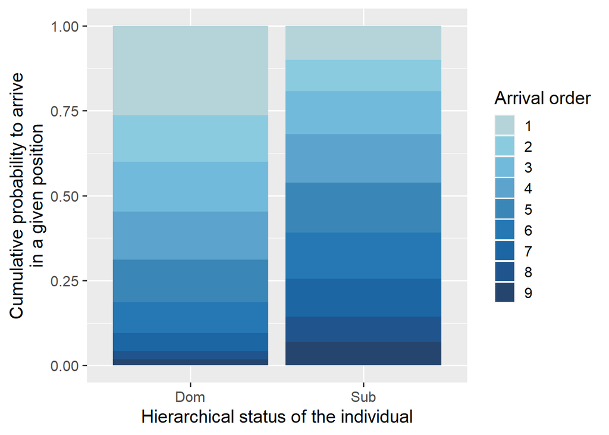

```r
ORE_clmm2_min_pred %>%
  ggplot(aes(x = Status, y = prob, fill = Arrival.order)) +
  geom_bar(position = "fill", stat = "identity") +
  scale_fill_discrete(type = paletteer_c("ggthemes::Classic Blue", 9)) +
  labs(x = "Hierarchical status of the individual",
       y = "Cumulative probability to arrive\nin a given position",
       fill = "Arrival order") +
  theme_gray(base_size = 15)
```

```r
# if you want, you can save this graph
#ggsave("ORE_clmm_Status.png", width = 8, height = 5, dpi = 600)
```

And now for the effect of foraging success:

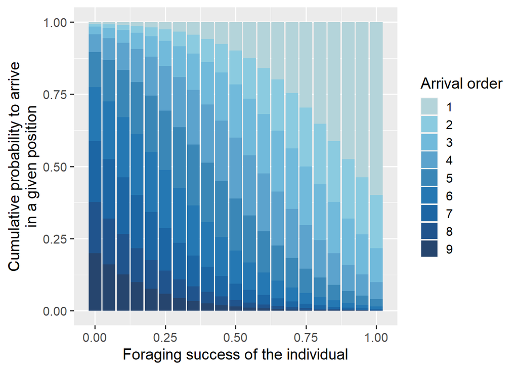

```r
ORE_clmm2_min_pred %>%
  ggplot(aes(x = Foraging.success, y = prob, fill = Arrival.order)) +
  geom_bar(position = "fill", stat = "identity") +
  scale_fill_discrete(type = paletteer_c("ggthemes::Classic Blue", 9)) +
  labs(x = "Foraging success of the individual",
       y = "Cumulative probability to arrive\nin a given position",
       fill = "Arrival order") +
  theme_gray(base_size = 15)
```

```r
# if you want, you can save this graph
#ggsave("ORE_clmm_ForagingSuccess.png", width = 8, height = 5, dpi = 600)
```

You can compare both graphs with the oberved values we computed at the beginning of the script.

### 3B. Logistic regression using `glmer()` (from the “`lme4`” package)

The `glmer()` function allows for nested random effects. We will nest Test within Group (each group had 3 different tests) and add Individual as a non-nested random effect. Logistic regressions can be fitted by specifying `family = binomial`:

```r
ORE_glmer_bin <- glmer(Arrival.bin ~ Status * Foraging.success +
                         (1|Group/Test) + (1|Individual), family = binomial, data = ORE)
```

```
## boundary (singular) fit: see help('isSingular')
```

```r
summary(ORE_glmer_bin)
```

```
## Generalized linear mixed model fit by maximum likelihood (Laplace
##   Approximation) [glmerMod]
##  Family: binomial  ( logit )
## Formula: Arrival.bin ~ Status * Foraging.success + (1 | Group/Test) +
##     (1 | Individual)
##    Data: ORE
##
##      AIC      BIC   logLik deviance df.resid
##     84.7    105.0    -35.4     70.7      128
##
## Scaled residuals:
##     Min      1Q  Median      3Q     Max
## -1.2089 -0.2996 -0.1093 -0.0335  6.0561
##
## Random effects:
##  Groups     Name        Variance Std.Dev.
##  Individual (Intercept) 0.3882   0.6231
##  Test:Group (Intercept) 0.0000   0.0000
##  Group      (Intercept) 0.0000   0.0000
## Number of obs: 135, groups:  Individual, 45; Test:Group, 18; Group, 6
##
## Fixed effects:
##                            Estimate Std. Error z value Pr(>|z|)
## (Intercept)                 -7.6837     3.6179  -2.124   0.0337 *
## StatusSub                   -0.2678     3.7988  -0.071   0.9438
## Foraging.success             9.1524     4.5462   2.013   0.0441 *
## StatusSub:Foraging.success  -0.9515     4.8212  -0.197   0.8436
## ---
## Signif. codes:  0 '***' 0.001 '**' 0.01 '*' 0.05 '.' 0.1 ' ' 1
##
## Correlation of Fixed Effects:
##             (Intr) SttsSb Frgng.
## StatusSub   -0.778
## Frgng.sccss -0.989  0.762
## SttsSb:Frg.  0.799 -0.980 -0.806
## optimizer (Nelder_Mead) convergence code: 0 (OK)
## boundary (singular) fit: see help('isSingular')
```

Again, we can get rid of the interaction, as it is not significant:

```r
ORE_glmer_bin_min <- glmer(Arrival.bin ~ Status + Foraging.success +
                             (1|Group/Test) + (1|Individual), family = binomial, data = ORE)
```

```
## boundary (singular) fit: see help('isSingular')
```

```r
summary(ORE_glmer_bin_min)
```

```
## Generalized linear mixed model fit by maximum likelihood (Laplace
##   Approximation) [glmerMod]
##  Family: binomial  ( logit )
## Formula: Arrival.bin ~ Status + Foraging.success + (1 | Group/Test) +
##     (1 | Individual)
##    Data: ORE
##
##      AIC      BIC   logLik deviance df.resid
##     82.7    100.2    -35.4     70.7      129
##
## Scaled residuals:
##     Min      1Q  Median      3Q     Max
## -1.1944 -0.2984 -0.1109 -0.0333  6.5464
##
## Random effects:
##  Groups     Name        Variance  Std.Dev.
##  Individual (Intercept) 3.243e-01 5.695e-01
##  Test:Group (Intercept) 1.570e-08 1.253e-04
##  Group      (Intercept) 1.217e-09 3.489e-05
## Number of obs: 135, groups:  Individual, 45; Test:Group, 18; Group, 6
##
## Fixed effects:
##                  Estimate Std. Error z value Pr(>|z|)
## (Intercept)       -7.1390     2.1475  -3.324 0.000886 ***
## StatusSub         -1.0032     0.7341  -1.367 0.171766
## Foraging.success   8.4594     2.6716   3.166 0.001543 **
## ---
## Signif. codes:  0 '***' 0.001 '**' 0.01 '*' 0.05 '.' 0.1 ' ' 1
##
## Correlation of Fixed Effects:
##             (Intr) SttsSb
## StatusSub    0.079
## Frgng.sccss -0.969 -0.269
## optimizer (Nelder_Mead) convergence code: 0 (OK)
## boundary (singular) fit: see help('isSingular')
```

As can be seen, dominance status has no effect on the probability of arriving first. However, when looking at the whole arrival order, dominance status had a significant effect. This is because dominant individuals are more likely to arrive *among the first individuals*, rather *being first* more frequently than expected. Switching from ordinal to logistic regression reduces the amount of information in the data and may lead to different answers [admittedly to slightly different questions: switching from “who is among the first individuals to arrive?” to “who is the first individual to arrive?”].

### 3C. Linear regression using `lmer()` (from the “`lme4`” package)

The `lmer()` function allows for nested random effects, but the outcome variable needs to be numeric.

```r
ORE_lmer_lin <- lmer(as.numeric(Arrival.order) ~ Status * Foraging.success +
                       (1|Group/Test) + (1|Individual), data = ORE)
```

```
## boundary (singular) fit: see help('isSingular')
```

```r
summary(ORE_lmer_lin)
```

```
## Linear mixed model fit by REML ['lmerMod']
## Formula: as.numeric(Arrival.order) ~ Status * Foraging.success + (1 |
##     Group/Test) + (1 | Individual)
##    Data: ORE
##
## REML criterion at convergence: 508.5
##
## Scaled residuals:
##      Min       1Q   Median       3Q      Max
## -2.77467 -0.67237  0.01582  0.68224  2.12309
##
## Random effects:
##  Groups     Name        Variance Std.Dev.
##  Individual (Intercept) 0.0000   0.0000
##  Test:Group (Intercept) 0.0000   0.0000
##  Group      (Intercept) 0.1997   0.4469
##  Residual               2.5075   1.5835
## Number of obs: 135, groups:  Individual, 45; Test:Group, 18; Group, 6
##
## Fixed effects:
##                            Estimate Std. Error t value
## (Intercept)                  5.4607     0.6090   8.966
## StatusSub                    2.1285     0.6671   3.191
## Foraging.success            -4.1785     0.9429  -4.432
## StatusSub:Foraging.success  -1.5328     1.0998  -1.394
##
## Correlation of Fixed Effects:
##             (Intr) SttsSb Frgng.
## StatusSub   -0.830
## Frgng.sccss -0.850  0.775
## SttsSb:Frg.  0.728 -0.885 -0.857
## optimizer (nloptwrap) convergence code: 0 (OK)
## boundary (singular) fit: see help('isSingular')
```

```r
# output does not report p-values by default
# if you need them, you can do the following:
# library(afex)
# ORE_lmer_lin <- lmer(as.numeric(Arrival.order) ~ Status * Foraging.success +
#                        (1|Group/Test) + (1|Individual), data = ORE)
# summary(ORE_lmer_lin)
```

Again, we can get rid of the interaction, as it is not significant:

```r
ORE_lmer_lin_min <- lmer(as.numeric(Arrival.order) ~ Status + Foraging.success +
                           (1|Group/Test) + (1|Individual), data = ORE)
```

```
## boundary (singular) fit: see help('isSingular')
```

```r
summary(ORE_lmer_lin_min)
```

```
## Linear mixed model fit by REML ['lmerMod']
## Formula: as.numeric(Arrival.order) ~ Status + Foraging.success + (1 |
##     Group/Test) + (1 | Individual)
##    Data: ORE
##
## REML criterion at convergence: 512.5
##
## Scaled residuals:
##      Min       1Q   Median       3Q      Max
## -2.72544 -0.78293 -0.04554  0.71966  2.12377
##
## Random effects:
##  Groups     Name        Variance Std.Dev.
##  Individual (Intercept) 0.0000   0.0000
##  Test:Group (Intercept) 0.0000   0.0000
##  Group      (Intercept) 0.2103   0.4586
##  Residual               2.5225   1.5882
## Number of obs: 135, groups:  Individual, 45; Test:Group, 18; Group, 6
##
## Fixed effects:
##                  Estimate Std. Error t value
## (Intercept)        6.0789     0.4205  14.455
## StatusSub          1.3040     0.3109   4.194
## Foraging.success  -5.3043     0.4878 -10.874
##
## Correlation of Fixed Effects:
##             (Intr) SttsSb
## StatusSub   -0.580
## Frgng.sccss -0.637  0.070
## optimizer (nloptwrap) convergence code: 0 (OK)
## boundary (singular) fit: see help('isSingular')
```

The output is very similar to the output from the ordinal regression. However, the linear model does not respect the ordinal nature of the data.

Note that the random effect structure may not be perfectly reflecting the data in the various models. However, at least in our case, specifying other random effect structures [that would still make sense from a study design perspective] never give largely different outputs. You can try different random effect structures for yourself.

## 4. Bayesian approach: ordinal regression using `brm()` (from the “`brms`” package)

### 4A. Modelling

In the Bayesian framework, we need to define priors. The proposed ones are conservative and should not influence too much the derived inference. Feel free to try the code also with other (more or less informative) priors. The Bayesian approach is in general very powerful, but can sometimes be very time-consuming. Therefore, try to parallelizse the computations via the “`cores =`” argument. In order to avoid unnecessary computation time, it is helpful to indicate a “`file =`” argument, which enables to avoid recomputing the formula every time the command is re-run. The “`control =`” argument aims at avoiding convergence problems. With the proposed one, you should be ok for most models.

```r
ORE_brms <- brm(Arrival.order ~ Status * Foraging.success +
                  (1|Group/Test) + (1|Individual),
                family = cumulative,
                prior = c(prior(normal(0, 4), class = Intercept),
                          prior(normal(0, 4), class = b)),
                data = ORE,
                iter = 6000,
                warmup = 2000,
                chains = 4,
                cores = 4,
                control = list(adapt_delta = 0.999999, max_treedepth = 20),
                file = "ORE_brms.rds")
```

### 4B. Inspect the posterior distribution

Now, we can plot how the variables impact the distribution of the posterior

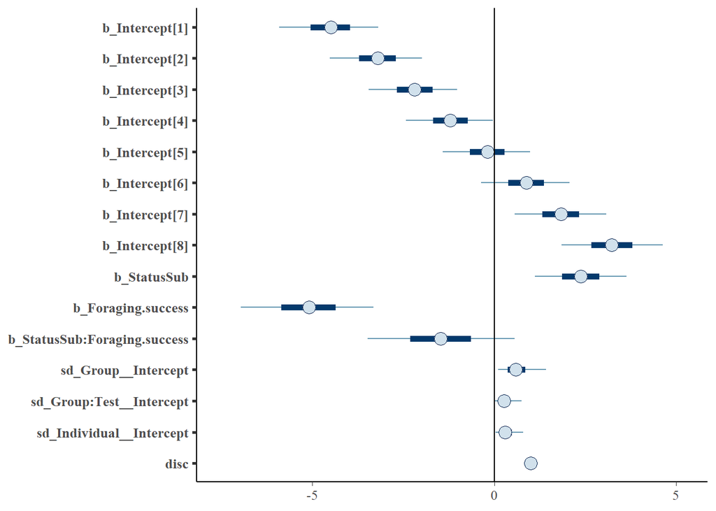

```r
mcmc_plot(ORE_brms) +
  geom_vline(aes(xintercept = 0))
```

The Bayesian approach requires the computation of sampling chains. We can inspect whether some issues are detected with this code:

```
## No divergences to plot.
```

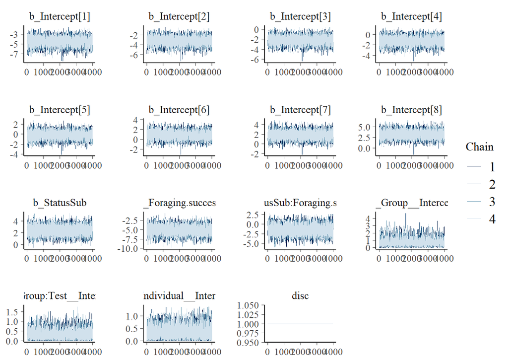

```r
mcmc_plot(ORE_brms, type = "trace")
```

In our case, no issue is detected (they would appear as red vertical lines: the less, the better).

We can look at how the posterior distribution is influenced by the variables:

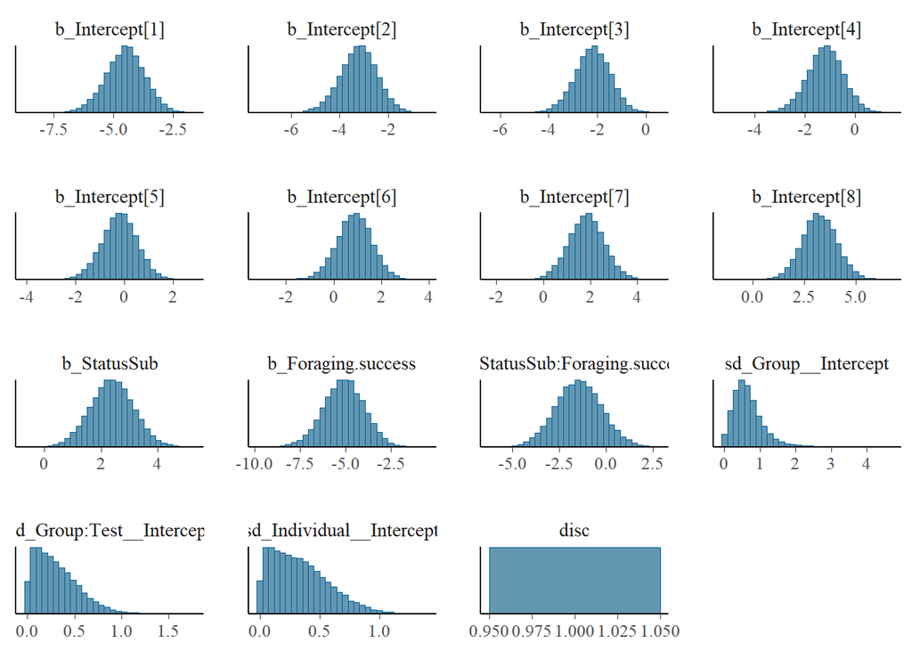

```r
mcmc_plot(ORE_brms, type = "hist")
```

We can also look at whether the sampling does a good job at approximating the response variable:

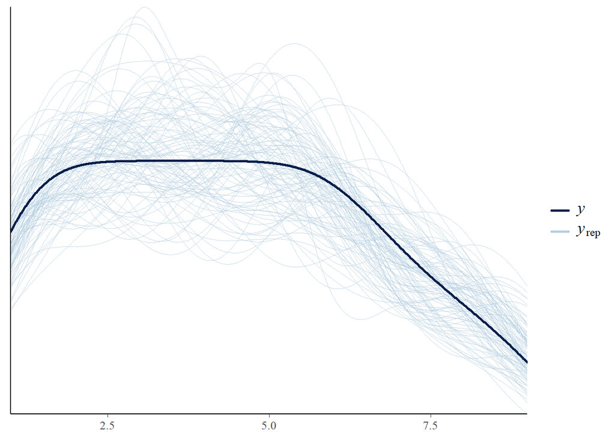

```r
pp_check(ORE_brms, ndraws = 100)
```

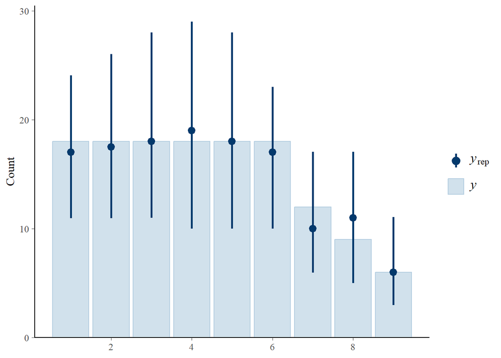

```r
pp_check(ORE_brms, type = "bars", ndraws = 100)
```

In the first graph, the distribution of the response variable is in dark blue, while the [100 randomly selected] sampled distributions are in light blue. In the second graph, the distribution of the response variable is in light blue, while the [100 randomly selected] sampled distributions are summarized in dark blue. Yeah, I know, it could be more consistent with the colours…

### 4C. Assess the impact of the fixed effects

Here is how to ask for the estimates of the fixed effects from the model:

```r
fixef(ORE_brms, robust = TRUE, prob = c(0.05, 0.95))
```

```
##                              Estimate Est.Error         Q5         Q95
## Intercept[1]               -4.4866280 0.8021300 -5.9031283 -3.18246019
## Intercept[2]               -3.2032179 0.7472096 -4.5165953 -1.98768384
## Intercept[3]               -2.1860775 0.7185632 -3.4417364 -1.02486691
## Intercept[4]               -1.2025800 0.7008145 -2.4306836 -0.03254705
## Intercept[5]               -0.1862630 0.7092916 -1.4160875  0.98047554
## Intercept[6]                0.8784427 0.7248352 -0.3585866  2.07046872
## Intercept[7]                1.8328552 0.7483752  0.5643741  3.08474163
## Intercept[8]                3.2195324 0.8334689  1.8494474  4.63408324
## StatusSub                   2.3826887 0.7605340  1.1183776  3.63490829
## Foraging.success           -5.0915386 1.1065077 -6.9600953 -3.31214249
## StatusSub:Foraging.success -1.4682970 1.2289015 -3.4844598  0.56289349
```

We can also assess whether the data gives credit to specific hypothesis:

```r
hypothesis(ORE_brms, "StatusSub > 0")
```

```
## Hypothesis Tests for class b:
##        Hypothesis Estimate Est.Error CI.Lower CI.Upper Evid.Ratio Post.Prob
## 1 (StatusSub) > 0     2.38      0.76     1.12     3.63       1999         1
##   Star
## 1    *
## ---
## 'CI': 90%-CI for one-sided and 95%-CI for two-sided hypotheses.
## '*': For one-sided hypotheses, the posterior probability exceeds 95%;
## for two-sided hypotheses, the value tested against lies outside the 95%-CI.
## Posterior probabilities of point hypotheses assume equal prior probabilities.
```

```r
hypothesis(ORE_brms, "Foraging.success < 0")
```

```
## Hypothesis Tests for class b:
##               Hypothesis Estimate Est.Error CI.Lower CI.Upper Evid.Ratio
## 1 (Foraging.success) < 0     -5.1      1.11    -6.96    -3.31        Inf
##   Post.Prob Star
## 1         1    *
## ---
## 'CI': 90%-CI for one-sided and 95%-CI for two-sided hypotheses.
## '*': For one-sided hypotheses, the posterior probability exceeds 95%;
## for two-sided hypotheses, the value tested against lies outside the 95%-CI.
## Posterior probabilities of point hypotheses assume equal prior probabilities.
```

```r
hypothesis(ORE_brms, "StatusSub:Foraging.success < 0")
```

```
## Hypothesis Tests for class b:
##                 Hypothesis Estimate Est.Error CI.Lower CI.Upper Evid.Ratio
## 1 (StatusSub:Foragi... < 0    -1.47      1.22    -3.48     0.56        7.8
##   Post.Prob Star
## 1      0.89
## ---
## 'CI': 90%-CI for one-sided and 95%-CI for two-sided hypotheses.
## '*': For one-sided hypotheses, the posterior probability exceeds 95%;
## for two-sided hypotheses, the value tested against lies outside the 95%-CI.
## Posterior probabilities of point hypotheses assume equal prior probabilities.
```

The sign for the inequality depends on the hypothesis you want to test. For instance, `"StatusSub > 0"` tests whether subordinate individuals arrive after dominant individuals. The reverse hypothesis would be specified with `"StatusSub < 0"`. If the value of `Post.Prob` is very close to 1, then the hypothesis is supported and there should be an asterisk in the `Star` column. As can be seen, the interaction between dominance status and foraging success is not supported by the data.

The `brms` package allows to (indirectly) compute effect sizes:

```r
ORE_brms_post <- as_draws_df(ORE_brms)
logitsd <- pi / sqrt(3) # constant used to transform log odds ratio into Cohen's d
# [could also be sqrt(3) / pi if * is used afterwards instead of /]
ORE_brms_Cohend_StatusForagingSuccess <- ORE_brms_post$`b_StatusSub:Foraging.success` / logitsd
median(ORE_brms_Cohend_StatusForagingSuccess); mad(ORE_brms_Cohend_StatusForagingSuccess)
```

```
## [1] -0.8095146
```

```
## [1] 0.6775289
```

```r
ORE_brms_Cohend_Status <- ORE_brms_post$`b_StatusSub` / logitsd
median(ORE_brms_Cohend_Status); mad(ORE_brms_Cohend_Status)
```

```
## [1] 1.313645
```

```
## [1] 0.4193044
```

```r
ORE_brms_Cohend_ForagingSuccess <- ORE_brms_post$`b_Foraging.success` / logitsd
median(ORE_brms_Cohend_ForagingSuccess); mad(ORE_brms_Cohend_ForagingSuccess)
```

```
## [1] -2.807112
```

```
## [1] 0.6100497
```

The effect sizes are reported in terms of median of the Cohen’s d and its associated Median Absolute Deviation [MAD].

### 4D. Visualization of the effects

Here are the default (not so readable) graphs easily accessible from the package:

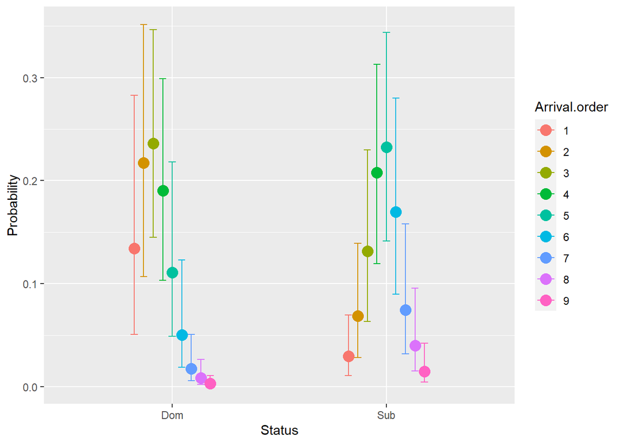

```r
conditional_effects(ORE_brms, effects = "Status", categorical = TRUE)
```

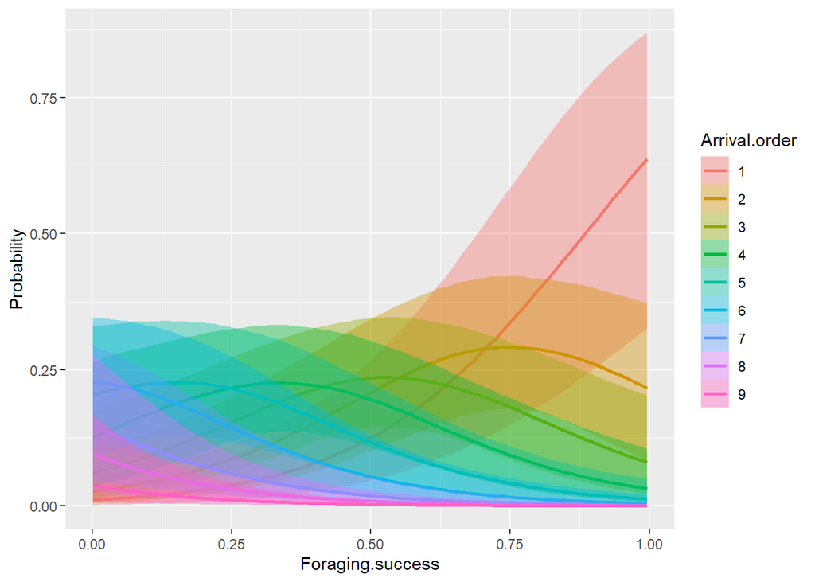

```r
conditional_effects(ORE_brms, effects = "Foraging.success", categorical = TRUE)
```

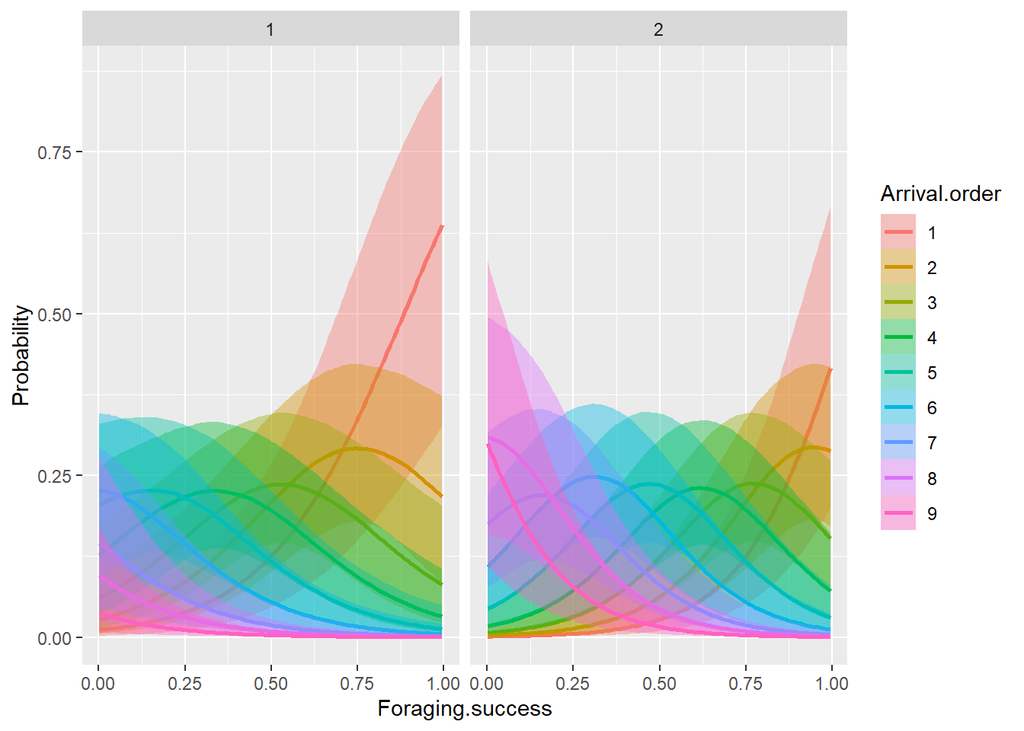

```r
conditional_effects(ORE_brms, effects = "Foraging.success", conditions = data.frame(Status = c("Dom", "Sub")), categorical = TRUE)
```

In order to get more readable visualizations, you can use the `ggplot2` package:

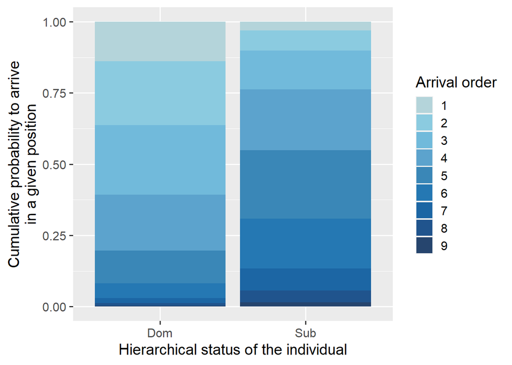

```r
ORE_brms_ce_Status <- conditional_effects(ORE_brms,
                                          effects = "Status",
                                          categorical = TRUE,
                                          prob = 0.90)

ORE_brms_ce_Status[[1]] %>%
  ggplot(aes(x = Status, y = estimate__, fill = effect2__)) +
  geom_bar(position = "fill", stat = "identity") +
  scale_fill_discrete(type = paletteer_c("ggthemes::Classic Blue", 9)) +
  labs(x = "Hierarchical status of the individual",
       y = "Cumulative probability to arrive\nin a given position",
       fill = "Arrival order") +
  theme_gray(base_size = 15)
```

```r
# if you want to save the graph
#ggsave("ORE_brms_ce_Status.png", width = 8, height = 5, dpi = 600)
```

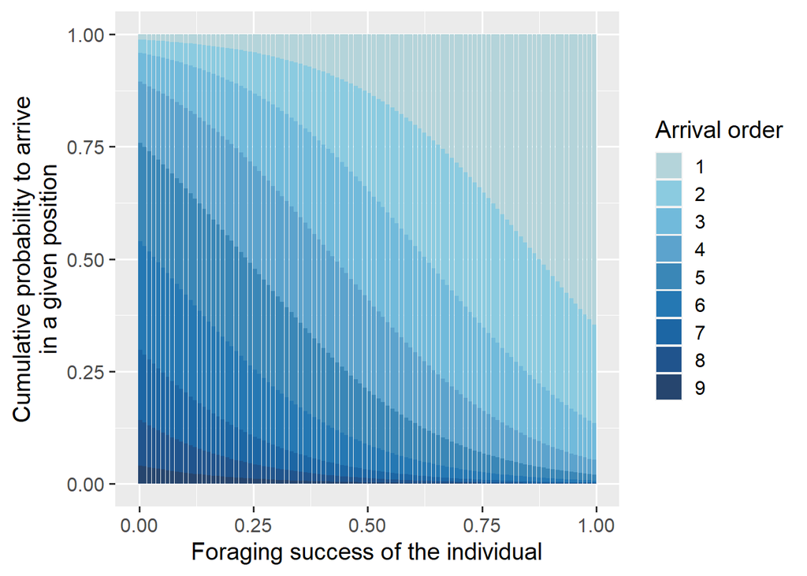

```r
ORE_brms_ce_ForagingSuccess <- conditional_effects(ORE_brms,
                                                   effects = "Foraging.success",
                                                   categorical = TRUE,
                                                   prob = 0.90)

ORE_brms_ce_ForagingSuccess[[1]] %>%
  ggplot(aes(x = Foraging.success, y = estimate__, fill = effect2__)) +
  geom_bar(position = "fill", stat = "identity") +
  scale_fill_discrete(type = paletteer_c("ggthemes::Classic Blue", 9)) +
  labs(x = "Foraging success of the individual",
       y = "Cumulative probability to arrive\nin a given position",
       fill = "Arrival order") +
  theme_gray(base_size = 15)
```

```r
# if you want to save the graph
#ggsave("ORE_brms_ce_ForagingSuccess.png", width = 8, height = 5, dpi = 600)
```

You can compare both graphs with the observed values and the graphs obtained with the frequentist approach.

## 5. Bayesian approach respecting the assumption that the same ordinal scale should be used across trials

Now, hold on, since the beginning, we treated all arrival orders as if they were comparable. But actually, some groups had a larger group size than others. Which means that the ordinal scale was ranging from 1 to 6 for some groups and from 1 to 9 for other groups. How to fix that? Well, we can bin the arrival orders into percentages. So instead of saying that this individual arrived second, we will say this individual arrived among the first 20% of group members.

Here is how to compute this new variable:

```r
ORE <- ORE %>%
  mutate(Arrival.order_rel = as.numeric(Arrival.order) / Group.size,
         Arrival.order_perc = ggplot2::cut_interval(Arrival.order_rel, length = 0.1, ordered_result = TRUE))
```

Finally, the full code for the `brms` implementation of the ordinal regression of percent arrival order:

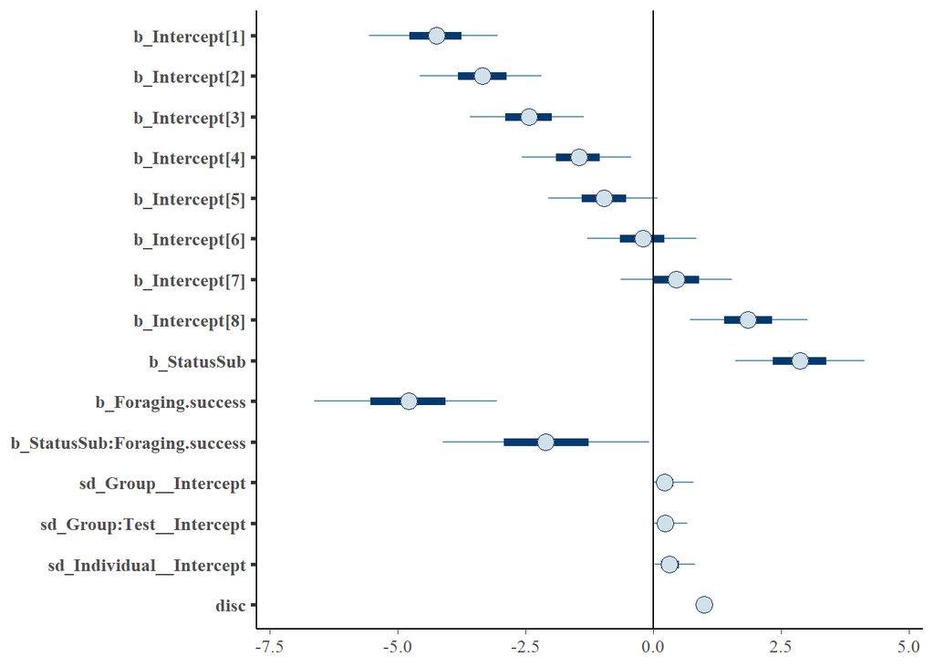

```r
ORE_brms_perc <- brm(Arrival.order_perc ~ Status * Foraging.success +
                       (1|Group/Test) + (1|Individual),
                     family = cumulative,
                     prior = c(prior(normal(0, 4), class = Intercept),
                               prior(normal(0, 4), class = b)),
                     data = ORE,
                     iter = 6000,
                     warmup = 2000,
                     chains = 4,
                     cores = 4,
                     control = list(adapt_delta = 0.999999, max_treedepth = 20),
                     file = "ORE_brms_perc.rds")


mcmc_plot(ORE_brms_perc) +
  geom_vline(aes(xintercept = 0))
```

```
## No divergences to plot.
```

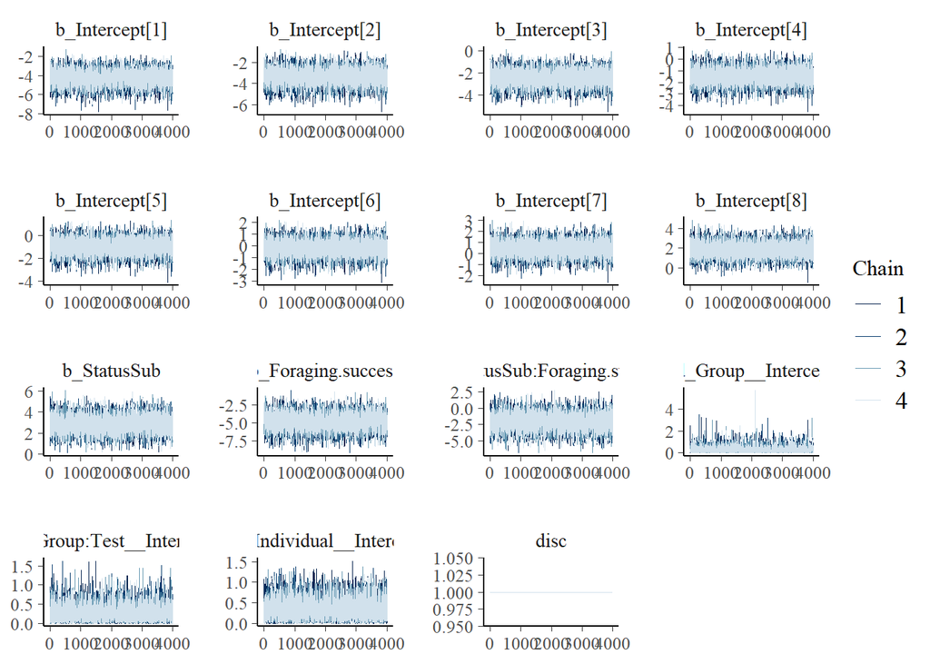

```r
mcmc_plot(ORE_brms_perc, type = "trace")
```

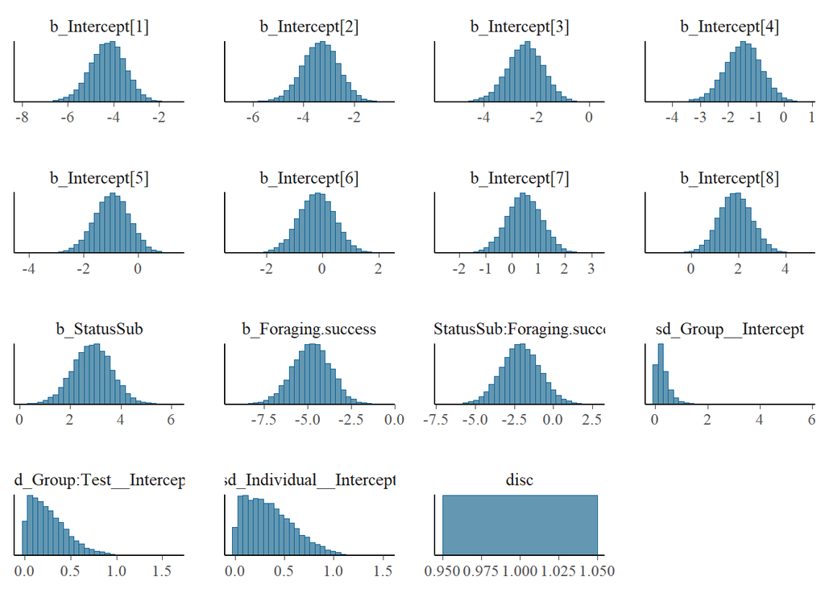

```r
mcmc_plot(ORE_brms_perc, type = "hist")
```

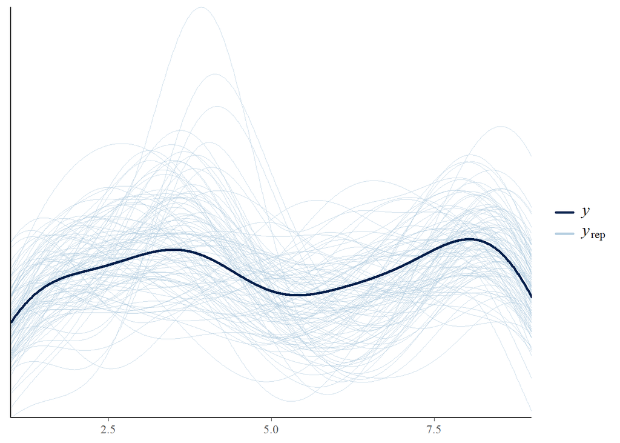

```r
pp_check(ORE_brms_perc, ndraws = 100)
```

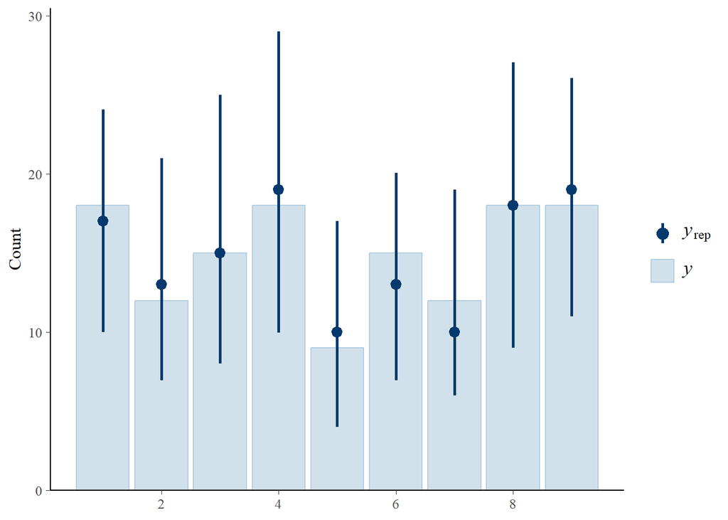

```r
pp_check(ORE_brms_perc, type = "bars", ndraws = 100)
```

```r
fixef(ORE_brms_perc, robust = TRUE, prob = c(0.05, 0.95))
```

```
##                              Estimate Est.Error         Q5         Q95
## Intercept[1]               -4.2345724 0.7543524 -5.5510493 -3.04014371
## Intercept[2]               -3.3324629 0.7083853 -4.5614604 -2.18118077
## Intercept[3]               -2.4326203 0.6771814 -3.5793206 -1.35570267
## Intercept[4]               -1.4563359 0.6404238 -2.5651404 -0.42678138
## Intercept[5]               -0.9557873 0.6377653 -2.0442033  0.07854197
## Intercept[6]               -0.2055840 0.6433185 -1.2862832  0.83774620
## Intercept[7]                0.4509590 0.6565292 -0.6351503  1.53740556
## Intercept[8]                1.8512471 0.7001877  0.7190070  3.01598859
## StatusSub                   2.8669428 0.7710127  1.6084552  4.13509996
## Foraging.success           -4.7759375 1.0925689 -6.6244955 -3.05968464
## StatusSub:Foraging.success -2.0998253 1.2316311 -4.1080456 -0.07377226
```

```r
hypothesis(ORE_brms_perc, "StatusSub > 0")
```

```
## Hypothesis Tests for class b:
##        Hypothesis Estimate Est.Error CI.Lower CI.Upper Evid.Ratio Post.Prob
## 1 (StatusSub) > 0     2.86      0.77     1.61     4.14        Inf         1
##   Star
## 1    *
## ---
## 'CI': 90%-CI for one-sided and 95%-CI for two-sided hypotheses.
## '*': For one-sided hypotheses, the posterior probability exceeds 95%;
## for two-sided hypotheses, the value tested against lies outside the 95%-CI.
## Posterior probabilities of point hypotheses assume equal prior probabilities.
```

```r
hypothesis(ORE_brms_perc, "Foraging.success < 0")
```

```
## Hypothesis Tests for class b:
##               Hypothesis Estimate Est.Error CI.Lower CI.Upper Evid.Ratio
## 1 (Foraging.success) < 0     -4.8       1.1    -6.62    -3.06        Inf
##   Post.Prob Star
## 1         1    *
## ---
## 'CI': 90%-CI for one-sided and 95%-CI for two-sided hypotheses.
## '*': For one-sided hypotheses, the posterior probability exceeds 95%;
## for two-sided hypotheses, the value tested against lies outside the 95%-CI.
## Posterior probabilities of point hypotheses assume equal prior probabilities.
```

```r
hypothesis(ORE_brms_perc, "StatusSub:Foraging.success < 0")
```

```
## Hypothesis Tests for class b:
##                 Hypothesis Estimate Est.Error CI.Lower CI.Upper Evid.Ratio
## 1 (StatusSub:Foragi... < 0    -2.09      1.24    -4.11    -0.07       21.1
##   Post.Prob Star
## 1      0.95    *
## ---
## 'CI': 90%-CI for one-sided and 95%-CI for two-sided hypotheses.
## '*': For one-sided hypotheses, the posterior probability exceeds 95%;
## for two-sided hypotheses, the value tested against lies outside the 95%-CI.
## Posterior probabilities of point hypotheses assume equal prior probabilities.
```

```r
# now also the interaction is significant

# effect sizes
ORE_brms_perc_post <- as_draws_df(ORE_brms_perc)
logitsd <- pi / sqrt(3) # constant used to transform log odds ratio into Cohen's d
# [could also be sqrt(3) / pi if * is used afterwards instead of /]
ORE_brms_perc_Cohend_StatusForagingSuccess <- ORE_brms_perc_post$`b_StatusSub:Foraging.success` / logitsd
median(ORE_brms_perc_Cohend_StatusForagingSuccess); mad(ORE_brms_perc_Cohend_StatusForagingSuccess)
```

```
## [1] -1.157694
```

```
## [1] 0.6790338
```

```r
ORE_brms_perc_Cohend_Status <- ORE_brms_perc_post$`b_StatusSub` / logitsd
median(ORE_brms_perc_Cohend_Status); mad(ORE_brms_perc_Cohend_Status)
```

```
## [1] 1.580628
```

```
## [1] 0.4250816
```

```r
ORE_brms_perc_Cohend_ForagingSuccess <- ORE_brms_perc_post$`b_Foraging.success` / logitsd
median(ORE_brms_perc_Cohend_ForagingSuccess); mad(ORE_brms_perc_Cohend_ForagingSuccess)
```

```
## [1] -2.633112
```

```
## [1] 0.6023648
```

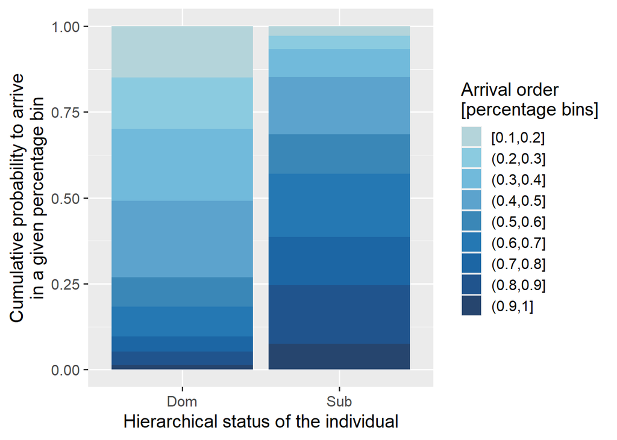

```r
# graph of effects
ORE_brms_perc_ce_Status <- conditional_effects(ORE_brms_perc,
                                          effects = "Status",
                                          categorical = TRUE,
                                          prob = 0.90)

ORE_brms_perc_ce_Status[[1]] %>%
  ggplot(aes(x = Status, y = estimate__, fill = effect2__)) +
  geom_bar(position = "fill", stat = "identity") +
  scale_fill_discrete(type = paletteer_c("ggthemes::Classic Blue", 9)) +
  labs(x = "Hierarchical status of the individual",
       y = "Cumulative probability to arrive\nin a given percentage bin",
       fill = "Arrival order\n[percentage bins]") +
  theme_gray(base_size = 15)
```

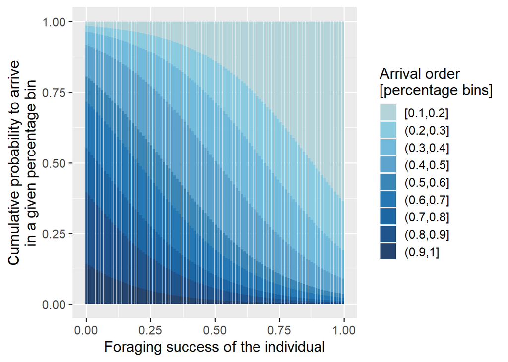

```r
ggsave("ORE_brms_perc_ce_Status.png", width = 8, height = 5, dpi = 600)


ORE_brms_perc_ce_ForagingSuccess <- conditional_effects(ORE_brms_perc,
                                                   effects = "Foraging.success",
                                                   categorical = TRUE,
                                                   prob = 0.90)

ORE_brms_perc_ce_ForagingSuccess[[1]] %>%
  ggplot(aes(x = Foraging.success, y = estimate__, fill = effect2__)) +
  geom_bar(position = "fill", stat = "identity") +
  scale_fill_discrete(type = paletteer_c("ggthemes::Classic Blue", 9)) +
  labs(x = "Foraging success of the individual",
       y = "Cumulative probability to arrive\nin a given percentage bin",
       fill = "Arrival order\n[percentage bins]") +
  theme_gray(base_size = 15)
```

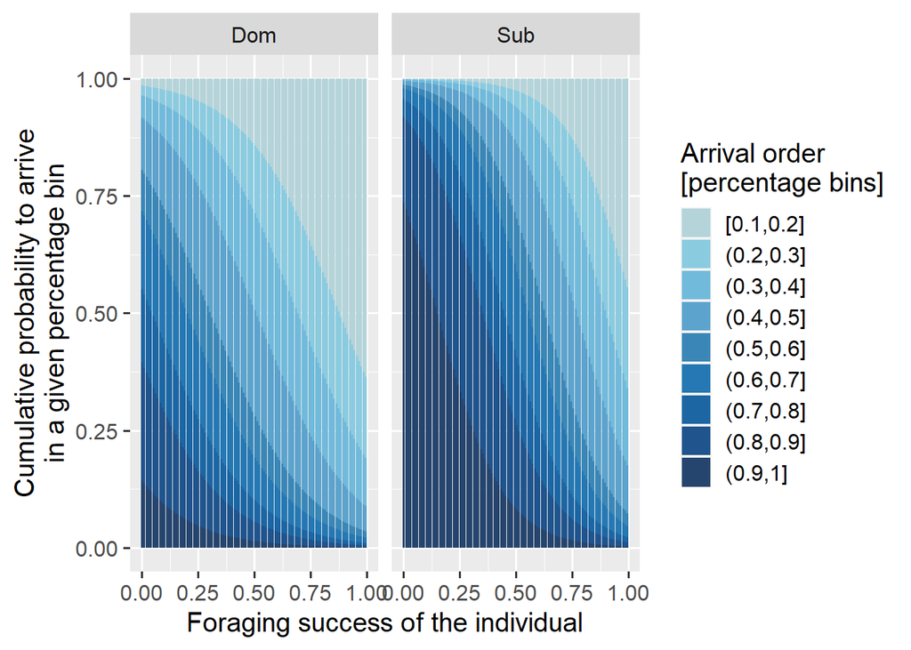

```r
# if you want to save this graph
#ggsave("ORE_brms_perc_ce_ForagingSuccess.png", width = 8, height = 5, dpi = 600)



ORE_brms_perc_ce_Int_StatusForagingSuccess <- conditional_effects(ORE_brms_perc,
                                                                  effects = "Foraging.success",
                                                                  categorical = TRUE,
                                                                  conditions = data.frame(Status = c("Dom", "Sub")),
                                                                  prob = 0.90)

ORE_brms_perc_ce_Int_StatusForagingSuccess[[1]] %>%
  ggplot(aes(x = Foraging.success, y = estimate__, fill = effect2__)) +
  geom_bar(position = "fill", stat = "identity") +
  facet_grid(~ Status) +
  scale_fill_discrete(type = paletteer_c("ggthemes::Classic Blue", 9)) +
  labs(x = "Foraging success of the individual",
       y = "Cumulative probability to arrive\nin a given percentage bin",
       fill = "Arrival order\n[percentage bins]") +
  theme_gray(base_size = 15)
```

```r
# if you want to save this graph
#ggsave("ORE_brms_perc_ce_Int_StatusForagingSuccess.png", width = 8, height = 5, dpi = 600)
```

Note that with the new coding of arrival order (as a percentage), the interaction between foraging success and dominance status is now significant: subordinate individuals with lower foraging success are much more likely than dominant individuals with lower foraging success to arrive among the last individuals of their groups. Conversely, dominant individuals with higher foraging success are much more likely than subordinate individuals with higher foraging success to arrive among the first individuals of their groups.

If you meticulously compare the graph on the left for the interaction and the graph for the conditional effects for foraging success, you could see that they are the same. Why is that? It is because we use *conditional* effects. These effects are therefore conditioned on something else. If a model includes more than one explanatory variable, then the conditional effects for a given variable are conditioned on specific levels of the other variables. By default, these specific levels are the means for numeric variables and the reference level for categorical variables. So when we plot the conditional effects of the interaction, we have a graph for the effect of foraging success for both dominant individuals and subordinate individuals. But when we ask only to plot the conditional effects of foraging success, then the plot is only given for dominant individuals [the reference category]. These defaults can be modified via the “`conditions =`” argument.